# Basic example

```r
library(designit)
library(ggplot2)
library(dplyr)
library(tidyr)
```

# Plate layout with two factors

## The samples

Samples of a 2-condition in-vivo experiment are to be placed on 48 well plates.

These are the conditions

```r
# conditions to use
conditions <- data.frame(
  group = c(1, 2, 3, 4, 5),
  treatment = c(
    "vehicle", "TRT1", "TRT2",
    "TRT1", "TRT2"
  ),
  dose = c(0, 25, 25, 50, 50)
)

gt::gt(conditions)
```

| group | treatment | dose |
| --- | --- | --- |
| 1 | vehicle | 0 |
| 2 | TRT1 | 25 |
| 3 | TRT2 | 25 |
| 4 | TRT1 | 50 |
| 5 | TRT2 | 50 |

We will have 3 animals per groups with 4 replicates each

```r
# sample table (2 animals per group with 3 replicates)
n_reps <- 4
n_animals <- 3
animals <- bind_rows(replicate(n_animals, conditions, simplify = FALSE),
  .id = "animal"
)
samples <- bind_rows(replicate(n_reps, animals, simplify = FALSE),
  .id = "replicate"
) |>
  mutate(
    SampleID = paste0(treatment, "_", animal, "_", replicate),
    AnimalID = paste0(treatment, "_", animal)
  ) |>
  mutate(dose = factor(dose))

samples |>
  head(10) |>
  gt::gt()
```

| replicate | animal | group | treatment | dose | SampleID | AnimalID |
| --- | --- | --- | --- | --- | --- | --- |
| 1 | 1 | 1 | vehicle | 0 | vehicle_1_1 | vehicle_1 |
| 1 | 1 | 2 | TRT1 | 25 | TRT1_1_1 | TRT1_1 |
| 1 | 1 | 3 | TRT2 | 25 | TRT2_1_1 | TRT2_1 |
| 1 | 1 | 4 | TRT1 | 50 | TRT1_1_1 | TRT1_1 |
| 1 | 1 | 5 | TRT2 | 50 | TRT2_1_1 | TRT2_1 |
| 1 | 2 | 1 | vehicle | 0 | vehicle_2_1 | vehicle_2 |
| 1 | 2 | 2 | TRT1 | 25 | TRT1_2_1 | TRT1_2 |
| 1 | 2 | 3 | TRT2 | 25 | TRT2_2_1 | TRT2_2 |
| 1 | 2 | 4 | TRT1 | 50 | TRT1_2_1 | TRT1_2 |
| 1 | 2 | 5 | TRT2 | 50 | TRT2_2_1 | TRT2_2 |

## Plate layout requirements

Corner wells of the plates should be left empty. This means on a 48 well plate we can place 44 samples. Since we have 60 samples, they will fit on 2 plates

```r
n_samp <- nrow(samples)
n_loc_per_plate <- 48 - 4
n_plates <- ceiling(n_samp / n_loc_per_plate)

exclude_wells <- expand.grid(plate = seq(n_plates), column = c(1, 8), row = c(1, 6))
```

## Setting up a Batch container

Create a BatchContainer object that provides all possible locations

```r
bc <- BatchContainer$new(
  dimensions = c("plate" = n_plates, "column" = 8, "row" = 6),
  exclude = exclude_wells
)
bc
```

```
#> Batch container with 88 locations.
#>   Dimensions: plate, column, row
```

```r
bc$n_locations
```

```
#> [1] 88
```

```r
bc$exclude
```

```r
bc$get_locations() |> head()
```

```
#> # A tibble: 6 × 3
#>   plate column   row
#>   <int>  <int> <int>
#> 1     1      1     2
#> 2     1      1     3
#> 3     1      1     4
#> 4     1      1     5
#> 5     1      2     1
#> 6     1      2     2
```

## Moving samples

Use random assignment function to place samples to plate locations

```r
bc <- assign_random(bc, samples)

bc$get_samples()
```

```
#> # A tibble: 88 × 10
#>    plate column   row replicate animal group treatment dose  SampleID AnimalID
#>    <int>  <int> <int> <chr>     <chr>  <dbl> <chr>     <fct> <chr>    <chr>
#>  1     1      1     2 1         2          2 TRT1      25    TRT1_2_1 TRT1_2
#>  2     1      1     3 4         3          4 TRT1      50    TRT1_3_4 TRT1_3
#>  3     1      1     4 <NA>      <NA>      NA <NA>      <NA>  <NA>     <NA>
#>  4     1      1     5 3         1          4 TRT1      50    TRT1_1_3 TRT1_1
#>  5     1      2     1 <NA>      <NA>      NA <NA>      <NA>  <NA>     <NA>
#>  6     1      2     2 <NA>      <NA>      NA <NA>      <NA>  <NA>     <NA>
#>  7     1      2     3 4         2          2 TRT1      25    TRT1_2_4 TRT1_2
#>  8     1      2     4 2         1          2 TRT1      25    TRT1_1_2 TRT1_1
#>  9     1      2     5 2         2          4 TRT1      50    TRT1_2_2 TRT1_2
#> 10     1      2     6 <NA>      <NA>      NA <NA>      <NA>  <NA>     <NA>
#> # ℹ 78 more rows
```

```r
bc$get_samples(remove_empty_locations = TRUE)
```

```
#> # A tibble: 60 × 10
#>    plate column   row replicate animal group treatment dose  SampleID AnimalID
#>    <int>  <int> <int> <chr>     <chr>  <dbl> <chr>     <fct> <chr>    <chr>
#>  1     1      1     2 1         2          2 TRT1      25    TRT1_2_1 TRT1_2
#>  2     1      1     3 4         3          4 TRT1      50    TRT1_3_4 TRT1_3
#>  3     1      1     5 3         1          4 TRT1      50    TRT1_1_3 TRT1_1
#>  4     1      2     3 4         2          2 TRT1      25    TRT1_2_4 TRT1_2
#>  5     1      2     4 2         1          2 TRT1      25    TRT1_1_2 TRT1_1
#>  6     1      2     5 2         2          4 TRT1      50    TRT1_2_2 TRT1_2
#>  7     1      3     1 4         1          2 TRT1      25    TRT1_1_4 TRT1_1
#>  8     1      3     4 2         3          4 TRT1      50    TRT1_3_2 TRT1_3
#>  9     1      3     5 1         3          2 TRT1      25    TRT1_3_1 TRT1_3
#> 10     1      3     6 3         1          3 TRT2      25    TRT2_1_3 TRT2_1
#> # ℹ 50 more rows
```

Plot of the result using the `plot_plate` function

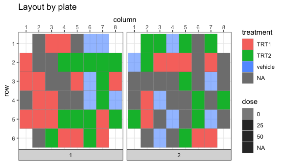

```r
plot_plate(bc,
  plate = plate, column = column, row = row,
  .color = treatment, .alpha = dose
)
```

To not show empty wells, we can directly plot the sample table as well

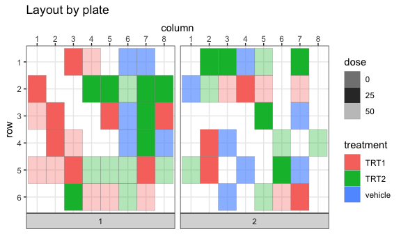

```r
plot_plate(bc$get_samples(remove_empty_locations = TRUE),
  plate = plate, column = column, row = row,
  .color = treatment, .alpha = dose
)
```

To move individual samples or manually assigning all locations we can use the `batchContainer$move_samples()` method

To swap two or more samples use:

**Warning**: This will change your BatchContainer in-place.

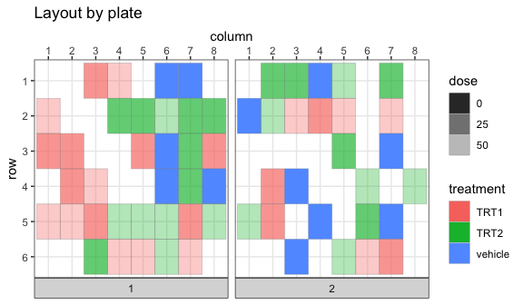

```r
bc$move_samples(src = c(1L, 2L), dst = c(2L, 1L))

plot_plate(bc$get_samples(remove_empty_locations = TRUE),
  plate = plate, column = column, row = row,
  .color = treatment, .alpha = dose
)
```

To assign all samples in one go, use the option `location_assignment`.

**Warning**: This will change your BatchContainer in-place.

The example below orders samples by ID and adds the empty locations afterwards

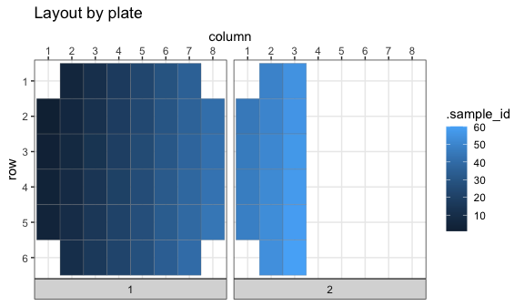

```r
bc$move_samples(
  location_assignment = c(
    1:nrow(samples),
    rep(NA, (bc$n_locations - nrow(samples)))
  )
)

plot_plate(bc$get_samples(remove_empty_locations = TRUE, include_id = TRUE),
  plate = plate, column = column, row = row,
  .color = .sample_id
)
```

## Run an optimization

To evaluate how good a layout is, we need a scoring function.

This function will assess how well treatment and dose are balanced across the two plates.

```r
bc <- optimize_design(bc,
  scoring = osat_score_generator(
    batch_vars = "plate",
    feature_vars = c("treatment", "dose")
  ),
  # shuffling schedule
  n_shuffle = c(rep(10, 200), rep(2, 400))
)
```

Development of the score can be viewed with

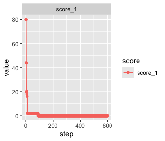

```r
bc$plot_trace()
```

The layout after plate batching looks the following

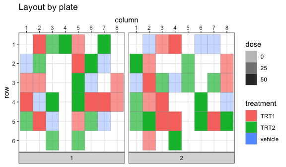

```r
plot_plate(bc$get_samples(remove_empty_locations = TRUE),
  plate = plate, column = column, row = row,
  .color = treatment, .alpha = dose
)
```

Looking at treatment, we see it’s evenly distributed across the plates

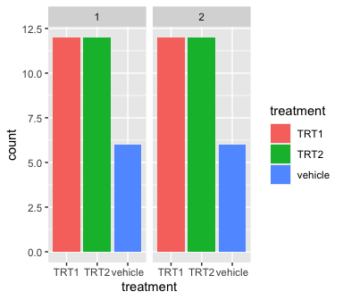

```r
ggplot(
  bc$get_samples(remove_empty_locations = TRUE),
  aes(x = treatment, fill = treatment)
) +
  geom_bar() +
  facet_wrap(~plate)
```

## Customizing the plate layout

To properly distinguish between empty and excluded locations one can do the following.

- Supply the BatchContainer directly
- set `add_excluded = TRUE`, set `rename_empty = TRUE`
- supply a custom color palette
- excluded wells have NA values and can be colored with `na.value`

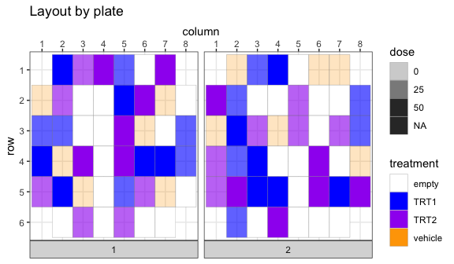

```r
color_palette <- c(
  TRT1 = "blue", TRT2 = "purple",
  vehicle = "orange", empty = "white"
)

plot_plate(bc,
  plate = plate, column = column, row = row,
  .color = treatment, .alpha = dose,
  add_excluded = TRUE, rename_empty = TRUE
) +
  scale_fill_manual(values = color_palette, na.value = "darkgray")
```

To remove all empty wells from the plot, hand the pruned sample list. to plot_plate rather than the whole BatchContainer. You can still assign your own colors.

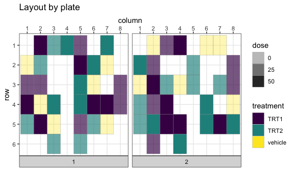

```r
plot_plate(bc$get_samples(remove_empty_locations = TRUE),
  plate = plate, column = column, row = row,
  .color = treatment, .alpha = dose
) +
  scale_fill_viridis_d()
```

Note: removing all empty and excluded wells will lead to omitting completely empty rows or columns!

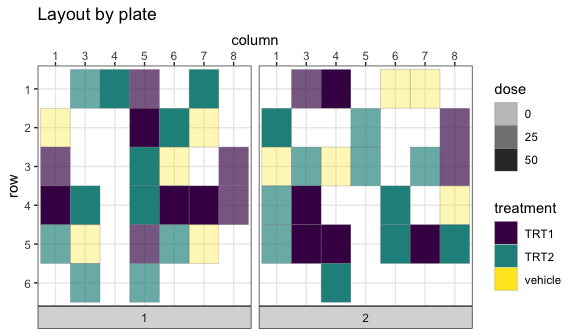

```r
plot_plate(bc$get_samples(remove_empty_locations = TRUE) |>
  filter(column != 2),
plate = plate, column = column, row = row,
.color = treatment, .alpha = dose
) +
  scale_fill_viridis_d()
```